# Consolidation Exercises

**ImportantModule workspace**

Download the ready-to-open workspace (.zip)

Unpack the file, then open the `.Rproj` project. The paths used in the exercises will work without moving the data.

These exercises are independent from the adventure and the challenge. They consolidate text analysis, lexical scores, TF-IDF and dashboard preparation using real public Quebec text.

The first file contains a balanced sample of descriptions from the [official Données Québec API](https://www.donneesquebec.ca/page-api/). The second comes from the Ministry of Tourism dataset [Événements - Système d’information touristique Québec](https://www.donneesquebec.ca/recherche/dataset/sit-quebec-evenements). Both sources are distributed under the CC BY 4.0 licence.

## Block A - Turn descriptions into tokens

### Exercise 1 - Import descriptions

Import `quebec_dataset_descriptions.csv`. Each row is a real portal record with its title, description, producer and category.

**NoteSolution**

```r
catalog <- read_csv(
  "data/quebec_dataset_descriptions.csv",
  show_col_types = FALSE
)

glimpse(catalog)
```

```
Rows: 89
Columns: 9
$ dataset_id     <chr> "pistes-cyclables-standard", "calendrier-de-collecte-de…
$ producer       <chr> "Ville de Gatineau", "Ville de Gatineau", "Ville de Gat…
$ category       <chr> "Infrastructures; Transport", "Environnement, ressource…
$ title          <chr> "Pistes cyclables", "Calendrier de collecte des matière…
$ description    <chr> "Pistes cyclables (standard du hackathon provincial à S…
$ resource_count <dbl> 5, 1, 2, 2, 3, 4, 3, 4, 4, 4, 4, 4, 4, 4, 4, 4, 3, 3, 3…
$ updated_at     <date> 2025-11-25, 2025-04-24, 2025-04-24, 2025-04-24, 2025-0…
$ licence        <chr> "Attribution (CC-BY 4.0)", "Attribution (CC-BY 4.0)", "…
$ snapshot_date  <date> 2026-07-11, 2026-07-11, 2026-07-11, 2026-07-11, 2026-0…
```

The sample contains 89 records from eight cities: Quebec City, Gatineau, Sherbrooke, Trois-Rivières, Saguenay, Laval, Longueuil and Montreal. Montreal accounts for one producer out of eight.

### Exercise 2 - Check the structure

**NoteSolution**

```r
catalog |>
  group_by(producer) |>
  summarise(
    records = n(),
    categories = n_distinct(category),
    .groups = "drop"
  ) |>
  arrange(desc(records), producer)
```

```
# A tibble: 8 × 3
  producer                                  records categories
  <chr>                                       <int>      <int>
1 Ville de Laval                                 12          6
2 Ville de Longueuil                             12          7
3 Ville de Montréal                              12          7
4 Ville de Québec                                12          5
5 Ville de Saguenay                              12          6
6 Ville de Sherbrooke - Données géomatiques      12          5
7 Ville de Trois-Rivières                        12          3
8 Ville de Gatineau                               5          2
```

The selection is balanced by producer, but does not represent the full catalog. It favours recently updated records with descriptions of at least 50 characters.

### Exercise 3 - Tokenize and remove stopwords

**NoteSolution**

```r
stop_fr <- stopwords("fr", source = "snowball")

catalog_tokens <- catalog |>
  unnest_tokens(word, description) |>
  filter(
    !word %in% stop_fr,
    str_detect(word, "^\\p{L}+$")
  )

catalog_tokens |>
  count(word, sort = TRUE) |>
  slice_head(n = 12)
```

```
# A tibble: 12 × 2
   word             n
   <chr>        <int>
 1 ville           53
 2 territoire      34
 3 cartographie    26
 4 données         23
 5 ensemble        16
 6 travaux         16
 7 type            16
 8 identifiant     15
 9 longueuil       13
10 rivières        13
11 zone            13
12 québec          12
```

Each row now represents a retained word. Frequencies offer a first view, but a description should be reread in context before interpretation.

### Exercise 4 - Compare words by producer

**NoteSolution**

```r
words_by_producer <- catalog_tokens |>
  count(producer, word, sort = TRUE) |>
  group_by(producer) |>
  slice_max(n, n = 5, with_ties = FALSE) |>
  ungroup()

words_by_producer
```

```
# A tibble: 40 × 3
   producer          word             n
   <chr>             <chr>        <int>
 1 Ville de Gatineau courant         10
 2 Ville de Gatineau zone             8
 3 Ville de Gatineau correspond       6
 4 Ville de Gatineau crue             6
 5 Ville de Gatineau gatineau         6
 6 Ville de Laval    territoire       9
 7 Ville de Laval    cartographie     6
 8 Ville de Laval    lavallois        6
 9 Ville de Laval    cdu              5
10 Ville de Laval    code             5
# ℹ 30 more rows
```

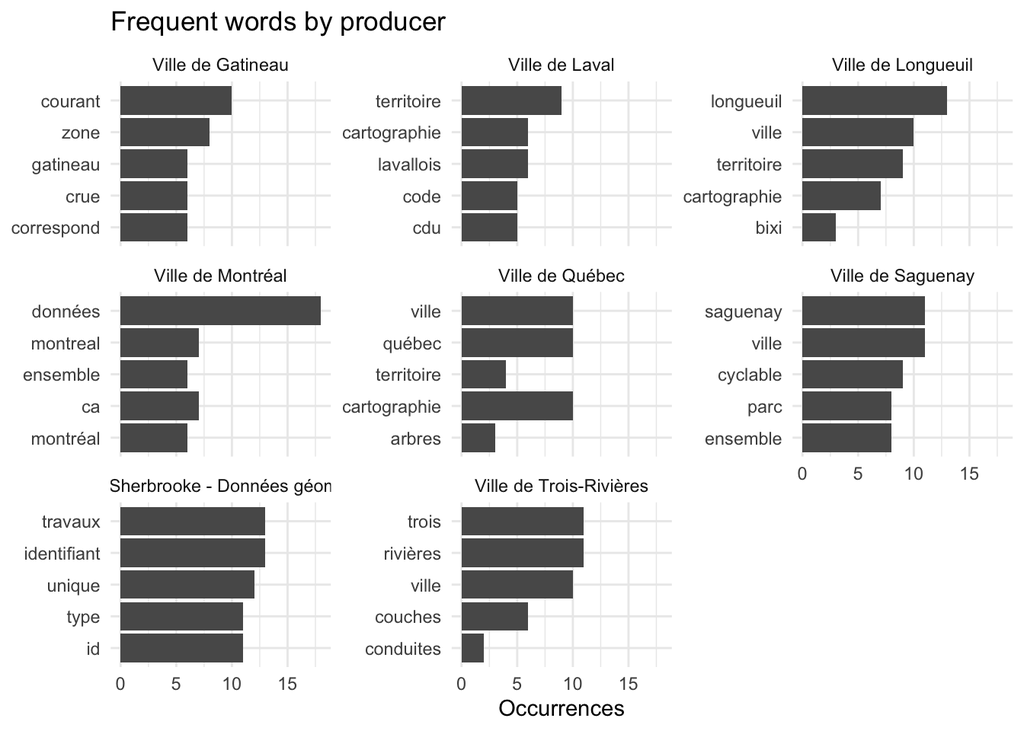

```r
ggplot(
  words_by_producer,
  aes(x = n, y = fct_reorder(word, n))
) +
  geom_col() +
  facet_wrap(vars(producer), scales = "free_y") +
  labs(
    x = "Occurrences",
    y = NULL,
    title = "Frequent words by producer"
  ) +
  theme_minimal()
```

A difference may come from published topics, institutional vocabulary or description length. It does not directly measure data quality.

## Block B - Build a simple lexical score

### Exercise 5 - Create a precision lexicon

Concrete terms receive `+1` and very general terms receive `-1`.

**NoteSolution**

```r
precision_lexicon <- tibble(
  word = c(
    "localisation", "inventaire", "nombre", "mesure", "date",
    "horaire", "statistiques", "registre", "liste", "géographique",
    "quotidien", "annuel", "donnée", "données", "information",
    "informations", "ensemble", "divers", "autre", "différents"
  ),
  class = c(rep("concrete", 12), rep("general", 8)),
  score = if_else(class == "concrete", 1, -1)
)

precision_lexicon
```

```
# A tibble: 20 × 3
   word         class    score
   <chr>        <chr>    <dbl>
 1 localisation concrete     1
 2 inventaire   concrete     1
 3 nombre       concrete     1
 4 mesure       concrete     1
 5 date         concrete     1
 6 horaire      concrete     1
 7 statistiques concrete     1
 8 registre     concrete     1
 9 liste        concrete     1
10 géographique concrete     1
11 quotidien    concrete     1
12 annuel       concrete     1
13 donnée       general     -1
14 données      general     -1
15 information  general     -1
16 informations general     -1
17 ensemble     general     -1
18 divers       general     -1
19 autre        general     -1
20 différents   general     -1
```

This score is not a validated measure of writing quality. It demonstrates lexicon scoring and must always be paired with human reading.

### Exercise 6 - Calculate a score by record

**NoteSolution**

```r
record_scores <- catalog_tokens |>
  inner_join(precision_lexicon, by = "word") |>
  group_by(dataset_id, producer, category) |>
  summarise(
    precision_score = sum(score),
    recognized_words = n(),
    .groups = "drop"
  ) |>
  right_join(
    catalog,
    by = c("dataset_id", "producer", "category")
  ) |>
  mutate(
    precision_score = replace_na(precision_score, 0),
    recognized_words = replace_na(recognized_words, 0),
    days_since_update = as.integer(snapshot_date - updated_at)
  )

record_scores |>
  select(
    dataset_id,
    producer,
    title,
    precision_score,
    recognized_words
  ) |>
  slice_head(n = 10)
```

```
# A tibble: 10 × 5
   dataset_id                    producer title precision_score recognized_words
   <chr>                         <chr>    <chr>           <dbl>            <int>
 1 04880bdf6ffa40ababfa900c2ef4… Ville d… Trav…               5                9
 2 728d843955a744c78dd6cd4b26b8… Ville d… Stat…               1                1
 3 arrondissements-longueuil     Ville d… Arro…               1                1
 4 chantiers-routiers            Ville d… Chan…               1                1
 5 infrastructure-pietonne       Ville d… Infr…              -1                1
 6 milieux-humides-rci           Ville d… Mili…              -3                3
 7 offres-d-emploi               Ville d… Offr…              -2                2
 8 permis-de-construction        Ville d… Perm…              -1                1
 9 permis-delivres-ville-de-que… Ville d… Perm…              -1                1
10 sag-reseau-routier            Ville d… Rése…              -1                1
```

A zero may mean neutral vocabulary or no match in the small lexicon. `recognized_words` is therefore essential.

### Exercise 7 - Summarize scores by producer

**NoteSolution**

```r
precision_by_producer <- record_scores |>
  group_by(producer) |>
  summarise(
    mean_score = mean(precision_score),
    mean_recognized_words = mean(recognized_words),
    mean_resources = mean(resource_count),
    records = n(),
    .groups = "drop"
  )

precision_by_producer
```

```
# A tibble: 8 × 5
  producer               mean_score mean_recognized_words mean_resources records
  <chr>                       <dbl>                 <dbl>          <dbl>   <int>
1 Ville de Gatineau          0                      0               2.6        5
2 Ville de Laval            -0.167                  0.333           3.83      12
3 Ville de Longueuil         0.0833                 0.25            3         12
4 Ville de Montréal         -1.17                   3.33            4.75      12
5 Ville de Québec           -0.167                  0.167           4.67      12
6 Ville de Saguenay         -0.667                  1               4.08      12
7 Ville de Sherbrooke -…     0.25                   1.08            6         12
8 Ville de Trois-Rivièr…     0                      0               3         12
```

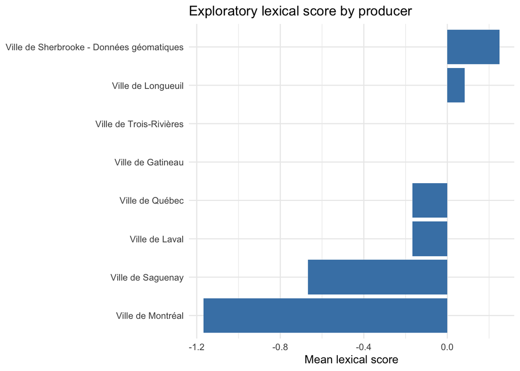

```r
ggplot(
  precision_by_producer,
  aes(x = mean_score, y = reorder(producer, mean_score))
) +
  geom_col(fill = "steelblue") +
  labs(
    x = "Mean lexical score",
    y = NULL,
    title = "Exploratory lexical score by producer"
  ) +
  theme_minimal()
```

The chart compares the sample, not overall producer quality. Topic and writing-style differences may explain part of the variation.

## Block C - Identify distinctive words

### Exercise 8 - Calculate TF-IDF by producer

**NoteSolution**

```r
producer_tfidf <- catalog_tokens |>
  count(producer, word) |>
  bind_tf_idf(word, producer, n) |>
  arrange(desc(tf_idf))

producer_tfidf |>
  group_by(producer) |>
  slice_max(tf_idf, n = 5, with_ties = FALSE) |>
  ungroup()
```

```
# A tibble: 40 × 6
   producer          word               n     tf   idf tf_idf
   <chr>             <chr>          <int>  <dbl> <dbl>  <dbl>
 1 Ville de Gatineau courant           10 0.0452  2.08 0.0941
 2 Ville de Gatineau correspond         6 0.0271  2.08 0.0565
 3 Ville de Gatineau crue               6 0.0271  2.08 0.0565
 4 Ville de Gatineau gatineau           6 0.0271  2.08 0.0565
 5 Ville de Gatineau grand              6 0.0271  2.08 0.0565
 6 Ville de Laval    lavallois          6 0.0392  2.08 0.0815
 7 Ville de Laval    cdu                5 0.0327  2.08 0.0680
 8 Ville de Laval    zaep               4 0.0261  2.08 0.0544
 9 Ville de Laval    architecturale     3 0.0196  2.08 0.0408
10 Ville de Laval    piia               3 0.0196  2.08 0.0408
# ℹ 30 more rows
```

A distinctive word is relatively more associated with one producer. It is not necessarily positive, negative or important to users.

### Exercise 9 - Visualize distinctive words

**NoteSolution**

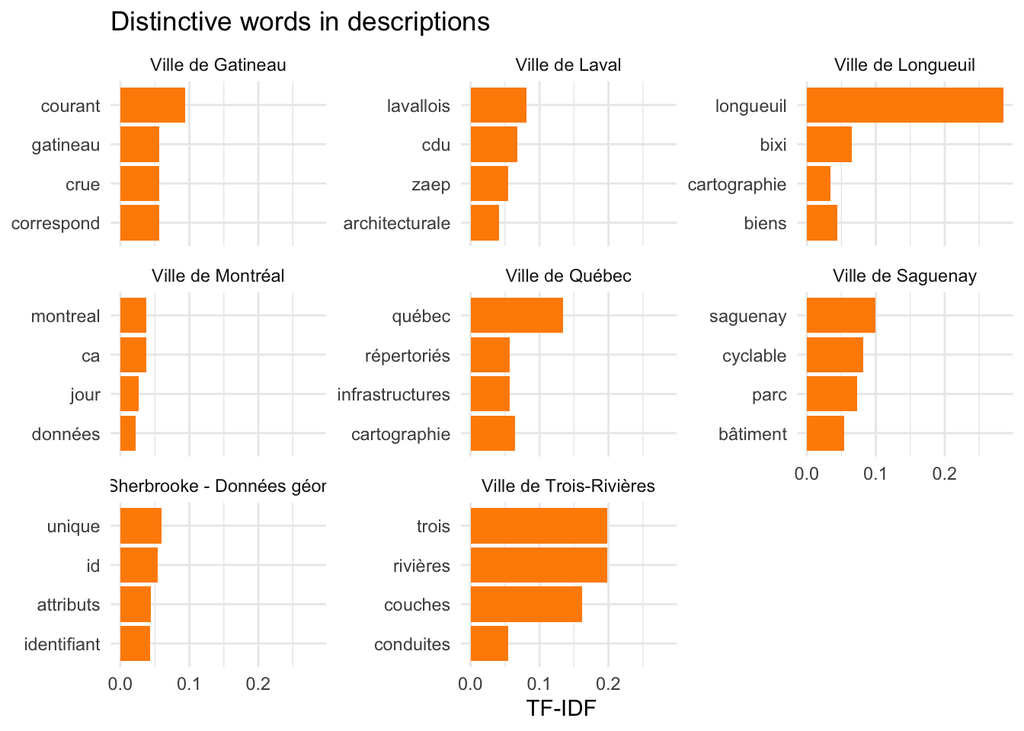

```r
tfidf_top <- producer_tfidf |>
  group_by(producer) |>
  slice_max(tf_idf, n = 4, with_ties = FALSE) |>
  ungroup() |>
  mutate(word = fct_reorder(word, tf_idf))

ggplot(tfidf_top, aes(x = tf_idf, y = word)) +
  geom_col(fill = "darkorange") +
  facet_wrap(vars(producer), scales = "free_y") +
  labs(
    x = "TF-IDF",
    y = NULL,
    title = "Distinctive words in descriptions"
  ) +
  theme_minimal()
```

Return to the original descriptions to check meaning before writing a conclusion.

## Block D - Prepare dashboard output

### Exercise 10 - Build a summary table

**NoteSolution**

```r
dashboard_summary <- record_scores |>
  group_by(producer) |>
  summarise(
    records = n(),
    mean_precision_score = mean(precision_score),
    mean_resources = mean(resource_count),
    median_days_since_update = median(days_since_update),
    categories = n_distinct(category),
    .groups = "drop"
  )

dashboard_summary
```

```
# A tibble: 8 × 6
  producer    records mean_precision_score mean_resources median_days_since_up…¹
  <chr>         <int>                <dbl>          <dbl>                  <dbl>
1 Ville de G…       5               0                2.6                     443
2 Ville de L…      12              -0.167            3.83                     92
3 Ville de L…      12               0.0833           3                       152
4 Ville de M…      12              -1.17             4.75                      0
5 Ville de Q…      12              -0.167            4.67                      6
6 Ville de S…      12              -0.667            4.08                     69
7 Ville de S…      12               0.25             6                        40
8 Ville de T…      12               0                3                         5
# ℹ abbreviated name: ¹median_days_since_update
# ℹ 1 more variable: categories <int>
```

This table separates indicator preparation from display. A dashboard could then present cards, charts and source descriptions.

### Exercise 11 - Simulate a filter

**NoteSolution**

```r
selected_producer <- "Ville de Québec"

dashboard_summary |>
  filter(producer == selected_producer)
```

```
# A tibble: 1 × 6
  producer    records mean_precision_score mean_resources median_days_since_up…¹
  <chr>         <int>                <dbl>          <dbl>                  <dbl>
1 Ville de Q…      12               -0.167           4.67                      6
# ℹ abbreviated name: ¹median_days_since_update
# ℹ 1 more variable: categories <int>
```

In a `shiny` app, this value could come from a menu. The analytical operation remains a filter on a prepared table.

## Case Study 1 - Quality of dataset descriptions

A team wants to identify descriptions that deserve editorial review.

**NoteSolution**

```r
records_to_review <- record_scores |>
  arrange(precision_score, recognized_words) |>
  select(
    producer,
    title,
    description,
    precision_score,
    recognized_words,
    days_since_update
  ) |>
  slice_head(n = 10)

records_to_review
```

```
# A tibble: 10 × 6
   producer title description precision_score recognized_words days_since_update
   <chr>    <chr> <chr>                 <dbl>            <int>             <int>
 1 Ville d… Inte… "Ensemble …              -4                6                 0
 2 Ville d… Mili… "Milieux h…              -3                3                39
 3 Ville d… Offr… "Ensemble …              -2                2                 5
 4 Ville d… Cale… "Cet ensem…              -2                2                 0
 5 Ville d… Résu… "Cet ensem…              -2                2                 0
 6 Ville d… Fréq… "Ensemble …              -2                4                 0
 7 Ville d… RSQA… "La Ville …              -2                8                 0
 8 Ville d… Infr… "Ensemble …              -1                1                 6
 9 Ville d… Perm… "Informati…              -1                1               102
10 Ville d… Perm… "Informati…              -1                1                 6
```

The score may prioritize reading, but should not automatically trigger correction. The lexicon is small, topics differ and a general description may still be accurate and useful.

## Case Study 2 - Quebec tourism events

Import `quebec_tourism_events.csv`. `text` combines public SIT Québec fields to create a short reproducible corpus.

**NoteSolution**

```r
events <- read_csv(
  "data/quebec_tourism_events.csv",
  show_col_types = FALSE
)

event_tokens <- events |>
  unnest_tokens(word, text) |>
  filter(
    !word %in% stop_fr,
    str_detect(word, "^\\p{L}+$")
  )

event_tfidf <- event_tokens |>
  count(event_type, word) |>
  bind_tf_idf(word, event_type, n) |>
  group_by(event_type) |>
  slice_max(tf_idf, n = 4, with_ties = FALSE) |>
  ungroup()

event_tfidf
```

```
# A tibble: 40 × 6
   event_type                        word            n     tf   idf tf_idf
   <chr>                             <chr>       <int>  <dbl> <dbl>  <dbl>
 1 Concert, spectacle                soirées         2 0.0435  2.30 0.100
 2 Concert, spectacle                chanson         2 0.0435  1.61 0.0700
 3 Concert, spectacle                contes          2 0.0435  1.61 0.0700
 4 Concert, spectacle                légendes        2 0.0435  1.61 0.0700
 5 Concours / tournoi                adulte          1 0.0556  2.30 0.128
 6 Concours / tournoi                deslauriers     1 0.0556  2.30 0.128
 7 Concours / tournoi                félix           1 0.0556  2.30 0.128
 8 Concours / tournoi                hallée          1 0.0556  2.30 0.128
 9 Expérience multimédia / immersive numériques      5 0.0704  1.61 0.113
10 Expérience multimédia / immersive immersif        3 0.0423  1.61 0.0680
# ℹ 30 more rows
```

```r
event_summary <- events |>
  group_by(tourism_region) |>
  summarise(
    events = n(),
    municipalities = n_distinct(municipality),
    median_duration_days = median(duration_days),
    proportion_with_website = mean(website_available),
    .groups = "drop"
  ) |>
  arrange(desc(events), tourism_region)

event_summary
```

```
# A tibble: 20 × 5
   tourism_region           events municipalities median_duration_days
   <chr>                     <int>          <int>                <dbl>
 1 Abitibi-Témiscamingue         8              5                  3
 2 Bas-Saint-Laurent             8              6                  4
 3 Cantons-de-l'Est              8              6                  1.5
 4 Centre-du-Québec              8              4                 16.5
 5 Charlevoix                    8              5                  3
 6 Chaudière-Appalaches          8              5                  3
 7 Côte-Nord (Manicouagan)       8              5                  4.5
 8 Gaspésie                      8              8                  7
 9 Lanaudière                    8              7                  3
10 Laurentides                   8              8                  2
11 Laval                         8              1                  4
12 Mauricie                      8              4                 21
13 Montréal                      8              1                656
14 Montérégie                    8              7                 33
15 Outaouais                     8              4                  3
16 Québec                        8              3                 19.5
17 Saguenay--Lac-Saint-Jean      8              7                  4.5
18 Îles-de-la-Madeleine          6              2                  5.5
19 Côte-Nord (Duplessis)         5              3                  4
20 Baie-James                    4              2                  6.5
# ℹ 1 more variable: proportion_with_website <dbl>
```

Useful visuals include a TF-IDF chart by event type and a regional coverage chart. The sample is balanced to at most eight events per tourism region, so it does not measure the true volume of the entire tourism offering.

[GPT STT-1100](https://chatgpt.com/g/g-682d165f32e881918633affa3fe9dfd6-gpt-stt-1100)